# Survey

Scott Brenstuhl

February 23, 2016

Ideas: Things by zipcode over time Parents vs not % of respondents with kids over the years (maybe also by zip) Peoples own neighborhoods vs city wide (by zip too) Correlation between cleanliness, lights, etc. and safety Match up Zipcode info with census data see how incomes etc. play in Tell the story of the mission & SOMA since people talk about them changing so much Mission zipcode: 94110 SOMA: 94103 Do changes over the years match up with 311 call learnings? All kinds of demographics info. Does it line up with Census data? People per household, up or down? Own or rent home What do people say in open ended comments?

Questions: How do I do the weighting for finweigh Neighborhoods mapped to zips?

regression table Arima, forcast package

6 and 7 should probably be made NA

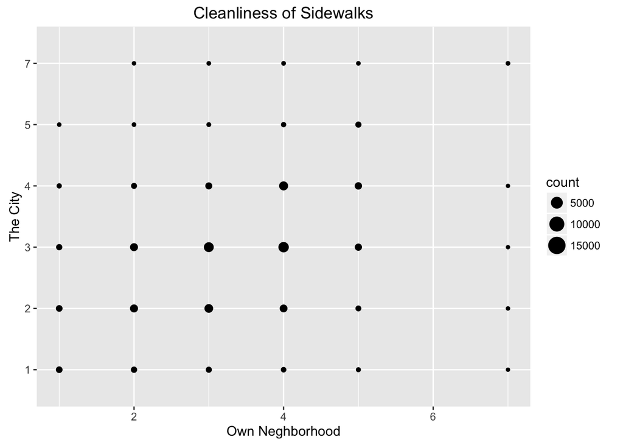

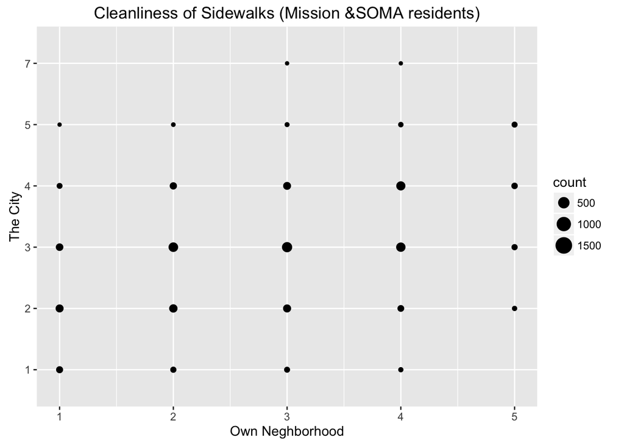

This needs to be a lot more digestable to be useful 2015, zip = NA remove after finding out why

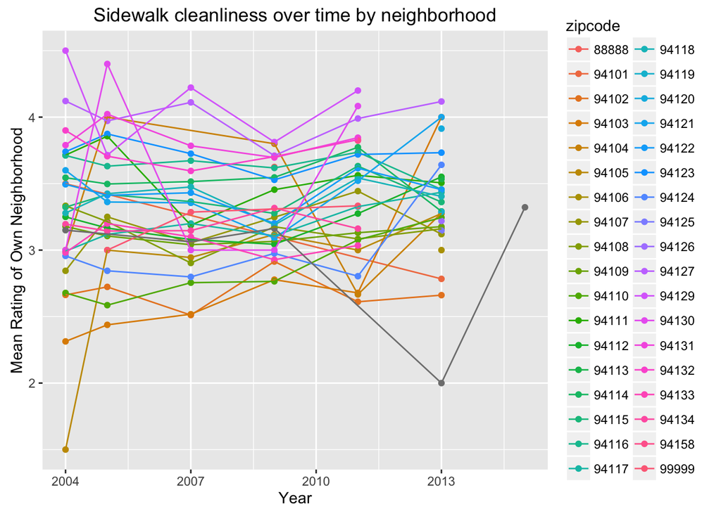

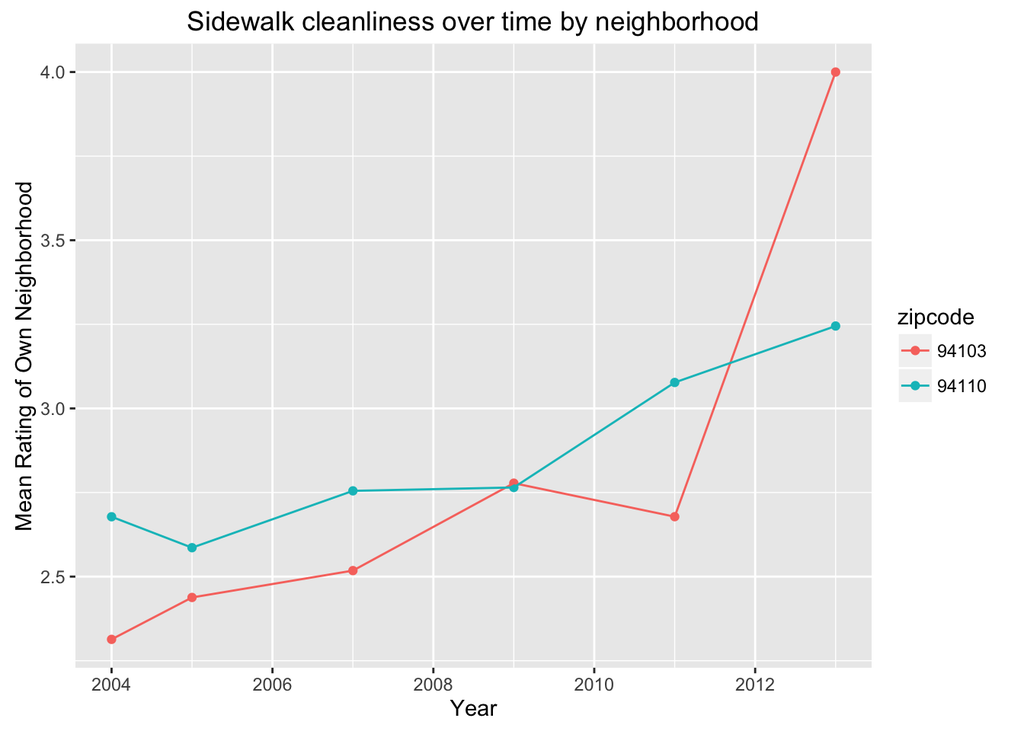

Lolllllllll Need a lot of zip cleaning and a better plan than facets

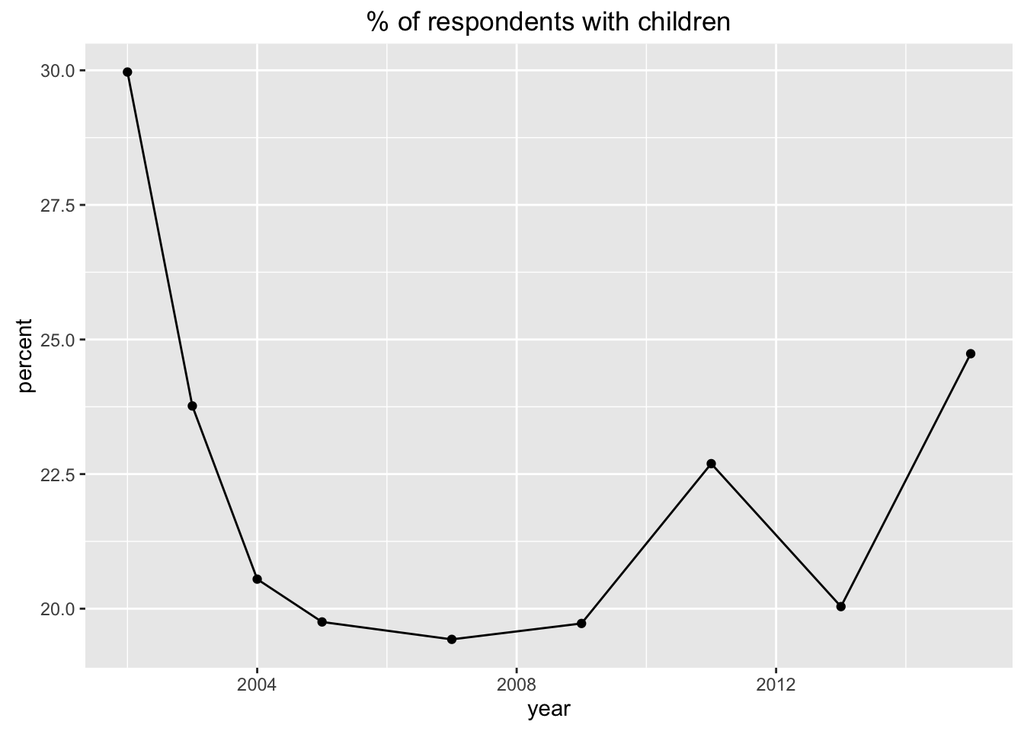

[interactive chart not shown]

The groupings in this changes so need to account for that.

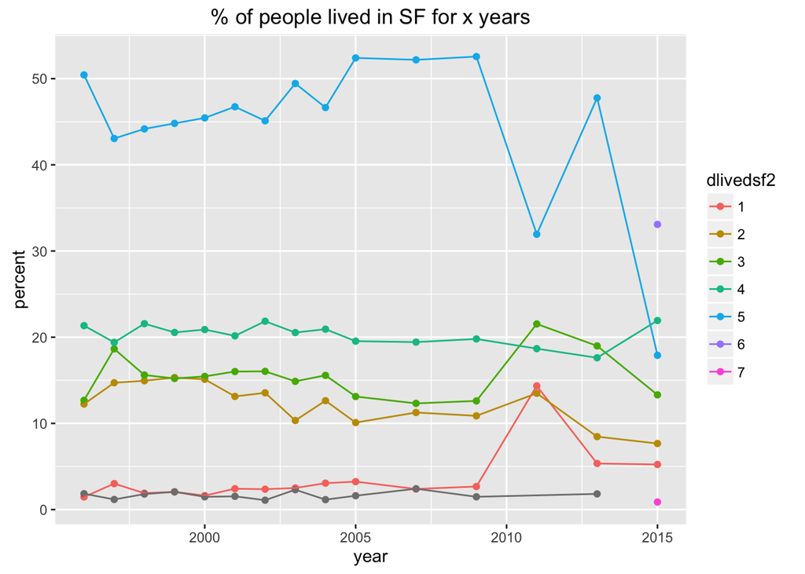

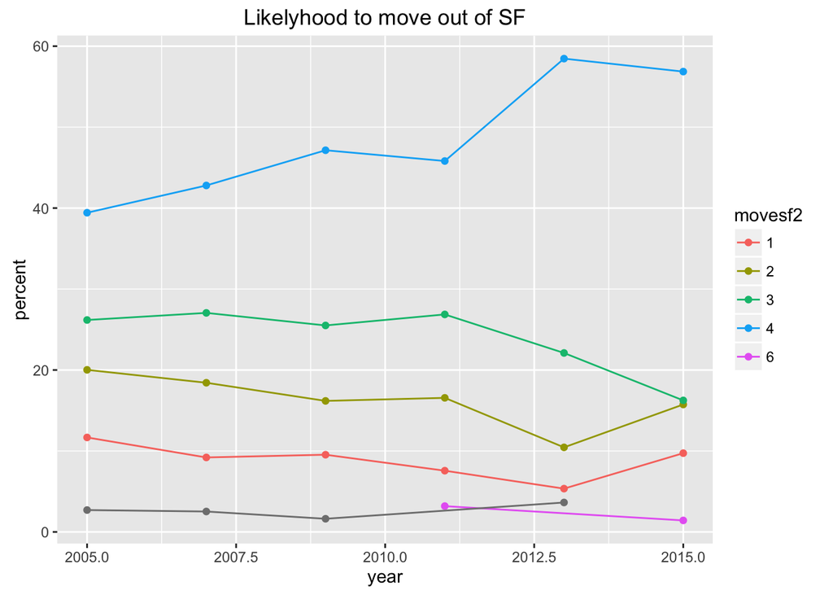